# HW5

When you are done:

1. Select ‘Run All’ from the ‘Run’ drop-down menu.
2. Save (File -> Save)
3. Click ‘Preview’ to bring up the `HW5.nb.html` file. Check through this to make sure it rendered correctly.
4. Upload the `HW5.nb.html` to Canvas.

Install new PLS205 package:

```r
# if you get an error with pls205_diagnostics, re-install the package here
# devtools::install_github('deruncie/PLS205_package')
```

```r
library(ggplot2)
library(emmeans)
library(PLS205)
library(lme4)
library(lmerTest)
```

This homework follows from Lab5 in investigating the effect of Nitrogen on potato yield.

The code below repeats the trend analysis of this experiment presented in lab. We’ll call this experimental design **Experiment 1**.

## 0.1 Experiment 1

An experiment was run to evaluate effects of increased nitrogen fertilization on tuber yield of Alpine Russet potatoes

- 5 nitrogen regimes: 0, 90, 150, 210, 270 lbs / acre at emergence
- 10 reps (plots) / Nitrogen level
- Response: total yield

**Design Table**

| Structure | Variable | Type | # levels | EU |
| --- | --- | --- | --- | --- |
| Treatment | Nitrogen | Numeric | 5 | NitrogenF |
| Design | NitrogenF | Categorical | 5 |  |
|  | Plot | Categorical | 50 |  |
| Response | Yield | Numeric | 50 |  |

Load the data and define a categorical variable for the EU:

```r
experiment1 = read.csv('~/Desktop/R_Projects/PLS205_Winter2021/PLS205_Winter2021/data/Experiment1.csv')
experiment1$NitrogenF = as.factor(experiment1$Nitrogen)
str(experiment1)
```

```
'data.frame':   50 obs. of  4 variables:
 $ Plot     : int  1 2 3 4 5 6 7 8 9 10 ...
 $ Nitrogen : int  270 0 210 150 150 90 270 210 270 90 ...
 $ Yield    : int  414 355 446 458 473 411 405 421 422 365 ...
 $ NitrogenF: Factor w/ 5 levels "0","90","150",..: 5 1 4 3 3 2 5 4 5 2 ...
```

Fit a degree-2 trend model

```r
expt1_deg2 = lmer(Yield ~ I(Nitrogen) + I(Nitrogen^2) + (1|NitrogenF), data = experiment1)
```

```
Some predictor variables are on very different scales: consider rescalingSome predictor variables are on very different scales: consider rescaling
```

Model diagnostics:

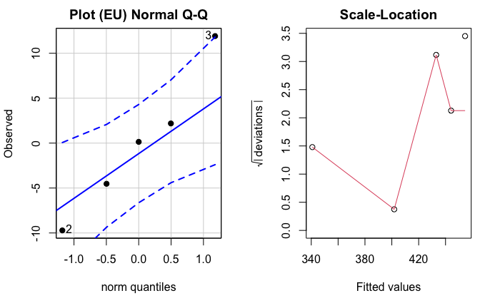

```r
pls205_diagnostics(expt1_deg2,EU = 'NitrogenF')
```

Visualize the fit and the confidence interval:

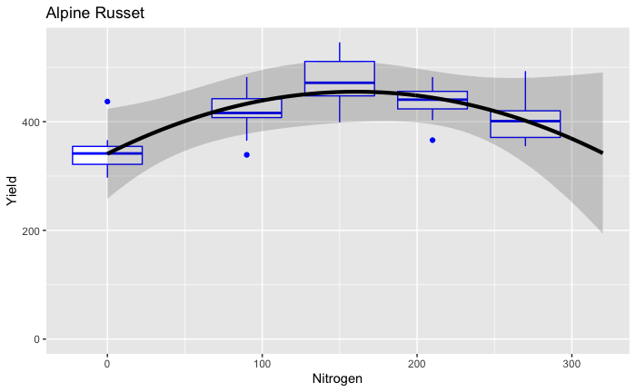

```r
# calculate the trend at a range of values of Nitrogen:
Nitrogen_range = seq(0,320,by=1)
expt1_deg2_means = emmeans(expt1_deg2,spec = 'Nitrogen',at=list(Nitrogen = Nitrogen_range))
expt1_deg2_means_summary = as.data.frame(summary(expt1_deg2_means,infer = c(T,F),level = 0.95))

# Plot the trend and its confidence intervals:
#   Inputs:
#      - `experiment1` the data table of the raw data
#      - `expt1_deg2_means_summary` table of estimates (emmean) and confidence intervals at each value of Nitrogen_range
#      * be sure to change these variable names in the code below to plot trends for other data/models

# Make a base plot with boxplots of the data
base_plot = ggplot(experiment1,aes(x=Nitrogen)) +
    geom_boxplot(aes(y=Yield,group = Nitrogen),color = 'blue',position = position_identity()) +
    ggtitle('Alpine Russet') + expand_limits(y=0)

# Then, add a line for the trend and a ribbon for the confidence intervals.
# Note, here we have to specify a new data table for the plot to use
base_plot +
    geom_ribbon(data = expt1_deg2_means_summary,aes(ymin = lower.CL,ymax = upper.CL),alpha = 0.2) +
    geom_line(data = expt1_deg2_means_summary,aes(y = emmean),size=1.5)
```

We will consider two alternate designs for this experiment in the problems below

# 1 Experiment 2

In an attempt to better characterize the Nitrogen response trend, the researcher modifies the experimental design to be the following:

- 10 nitrogen regimes: 0, 45, 90, 120, 150, 180, 210, 240, 270, 300 lbs / acre at emergence
- 5 rep (plot) / Nitrogen level
- Response: total yield

The data for this experiment is here:

```r
experiment2 = read.csv('~/Desktop/R_Projects/PLS205_Winter2021/PLS205_Winter2021/data/Experiment2.csv',stringsAsFactors=F)
str(experiment2)
```

[output not shown]

## 1.1 Prepare the design table for Experiment 2

**Note**: I recommend creating the table in Excel, copy/paste it into: https://www.tablesgenerator.com/markdown_tables under `File -> Paste table data...`, then copy the markdown and paste here:

| Structure | Variable | Type | # levels | EU |
| --- | --- | --- | --- | --- |
| Treatment | Nitrogen | Numeric | 10 | NitrogenF |
| Design | NitrogenF | Categorical | 10 |  |
|  | Plot | Categorical | 50 |  |
| Response | Yield | Numeric | 50 |  |

## 1.3 Fill in the missing values (denoted by ??) of the following ANOVA table

This is calculated for a trend on Nitrogen modeled with a polynomial. What was the degree of the polynomial?

| Source | Df | Sum_of_sq | Mean_sq | F-value | p-value |
| --- | --- | --- | --- | --- | --- |
| Nitrogen | 3 | 21980.4 | ?? | 4.4398 | 0.05735 |
| Error | ?? | 9901.5 | ?? |  |  |

```r
# Assigning table values to variables
DfT <- 3
SST <- 21980.4
F_val <- 4.4398
SSE <- 9901.5

# Calculating MST
MST = SST/DfT
MST
```

```
[1] 7326.8
```

```r
# Calculating MSE
MSE = MST/F_val
MSE
```

```
[1] 1650.255
```

```r
# Caclulating DfE
DfE = SSE / MSE
DfE
```

```
[1] 5.999984
```

```r
# Alternate DfE Calculation
```

[output not shown]

## 1.4 Choose a better polynomial trend model (if possible) based on these data and plot the fit + confidence ribbon

Here is some more background on choosing the best polynomial trend model:

The goal is to choose a model with enough, but not too many parameters (ie just the right degree). If the degree is too small, the model isn’t flexible enough to fit the real trend of the data, **ie it will give a biased prediction for some levels of Nitroge**. As the degree increases, a polynomial function can approximate almost any curve shape. But, higher degree means large DfT, potentially a wigglier (and less realistic) trend-line, and also the potential to over-fit the data. Over-fitting is similar to under-estimating confidence intervals and leads us to predict small-scale patterns (like increases-then decreases-then increases in Yield as we increase N) when they are not there.

I recommend you start with the following guidelines:

1. Choose a maximum degree for your model to start with:
- The maximum degree MUST be less than the number of EU. I wouldn’t go higher than #EU-3, and wouldn’t even go that high unless really needed.
- Unless your treatment covers a very large range and you have a lot of data, I wouldn’t try degrees > 5 or 6. Degree-5 polynomials already do a pretty good job of approximating most realistic response functions
2. Fit this model by spelling out each exponent of your treatment (`~I(Variable)+I(Variable^2)+I(Variable^3)+...`) and call it a “full trend”. This will be your reference for a model of maximum complexity.
3. Use the `anova` function to decide if the `full_trend` model is necessary.
- If you use `lmer` to fit your model, be sure to set the argument `ddf='Kenwood-Roger'` (`ddf = 'K'` for short), and the argument `type='I'`.
- The ANOVA will break up the Treatment model into a separate row for each exponent. Look specifically at the row corresponding to the highest power (it should be the last row). This row of the table constructs an F-statistic to test the null hypothesis that this highest power of your model is NOT IMPORTANT (i.e. $\beta_k = 0$ where $k$ is the highest power in your trend model). If these highest power is not important, you’d be better off dropping it. Make a decision based on the F-statistic (interpretation: larger F-statistics mean the term is more important. For example F_hat = 3 means that this exponent is roughly 3x as important as the deviations of level-means from your curve). But remember that F-statistics can be large by chance so the hypothesis test (p-value) can guide you whether this large an F could be by chance.
4. If the highest exponent is NOT SUFFICIENTLY important, then drop this term from your model, call it a `reduced_trend`, and re-fit. You’ll get a benefit from more degrees of freedom for error without compromising much in the trend itself.
5. Repeat 3-4 until the highest remaining power of your treatment is deemed **important** by the ANOVA.
6. Perform model diagnostics on this final model using the `pls205_diagnostics()` function.

The most difficult step here is Step 3. There’s an art to this, as much as a science. The easiest strategy is to simply choose an $\alpha$ threshold, and apply this to the p-value of the highest power term each time. I recommend that you choose a fairly liberal one like 0.1. If you end up with too-complex a model, your confidence intervals will be bigger. You do not need to correct for multiple testing in this context (at least for this course, your PI may have a different opinion but it is a judgment call).

Present your full model selection in code blocks below. For maximum transparency, I recommend using a different code block for each time through steps 3-5 and ending with the ANOVA for that model, and then making a comment after the code block describing why you chose to drop the highest-remaining term or not. You can receive full credit for a well-reasoned choice even if it doesn’t match the answer key exactly. End with your model diagnostics and a plot showing the fitted trend-line and confidence intervals as done above (reuse that code, but be sure to change the inputs!).

| Structure | Variable | Type | # levels | EU |
| --- | --- | --- | --- | --- |
| Treatment | Nitrogen | Numeric | 10 | NitrogenF |
| Design | NitrogenF | Categorical | 10 |  |
|  | Plot | Categorical | 50 |  |
| Response | Yield | Numeric | 50 |  |

```r
# adding NitrogenF to the data
experiment2$NitrogenF <- as.factor(experiment2$Nitrogen)

# code for full model
expt2_full_trend <- lmer(Yield ~ I(Nitrogen) + I(Nitrogen^2) + I(Nitrogen^3) + (1|NitrogenF), data = experiment2)
```

```
Some predictor variables are on very different scales: consider rescalingSome predictor variables are on very different scales: consider rescaling
```

```r
# running the ANOVA
anova(expt2_full_trend, ddf = 'K', type='I')
```

```
Type I Analysis of Variance Table with Kenward-Roger's method
               Sum Sq Mean Sq NumDF DenDF F value  Pr(>F)
I(Nitrogen)    2028.3  2028.3     1     6  0.9938 0.35730
I(Nitrogen^2) 24987.3 24987.3     1     6 12.2435 0.01284 *
I(Nitrogen^3)   167.5   167.5     1     6  0.0821 0.78415
---
Signif. codes:  0 ‘***’ 0.001 ‘**’ 0.01 ‘*’ 0.05 ‘.’ 0.1 ‘ ’ 1
```

```r
# code for full model
expt2_fuller_trend <- lmer(Yield ~ I(Nitrogen) + I(Nitrogen^2) + I(Nitrogen^3) + I(Nitrogen^4) + (1|NitrogenF), data = experiment2)
```

```
Some predictor variables are on very different scales: consider rescalingSome predictor variables are on very different scales: consider rescaling
```

```r
# running the ANOVA
anova(expt2_fuller_trend, ddf = 'K', type='I')
```

```
Type I Analysis of Variance Table with Kenward-Roger's method
              Sum Sq Mean Sq NumDF DenDF F value   Pr(>F)
I(Nitrogen)     7640    7640     1     5  3.7435 0.110805
I(Nitrogen^2)  94121   94121     1     5 46.1184 0.001054 **
I(Nitrogen^3)    631     631     1     5  0.3091 0.602181
I(Nitrogen^4)  35920   35920     1     5 17.6005 0.008528 **
---
Signif. codes:  0 ‘***’ 0.001 ‘**’ 0.01 ‘*’ 0.05 ‘.’ 0.1 ‘ ’ 1
```

> In the full trend model, the third term, I(Nitrogen^3) has a low F value and a high P value, indicating that this term is not important to the model.

```r
#code for first reduced model
expt2_deg2 <- lmer(Yield ~ I(Nitrogen) + I(Nitrogen^2) + (1|NitrogenF), data = experiment2)
```

```
Some predictor variables are on very different scales: consider rescalingSome predictor variables are on very different scales: consider rescaling
```

```r
# running the ANOVA
anova(expt2_deg2, ddf = 'K', type='I')
```

```
Type I Analysis of Variance Table with Kenward-Roger's method
               Sum Sq Mean Sq NumDF DenDF F value   Pr(>F)
I(Nitrogen)    2334.4  2334.4     1     7  1.1438 0.320333
I(Nitrogen^2) 28758.5 28758.5     1     7 14.0914 0.007132 **
---
Signif. codes:  0 ‘***’ 0.001 ‘**’ 0.01 ‘*’ 0.05 ‘.’ 0.1 ‘ ’ 1
```

> In the reduced model, the second (and final) term has a large F value (14.0914) and a low P value, indicating that this term is important in fitting our model. The low p value indicates that there is a low chance that the F value was high by chance.

[figure not shown]

```r
# code for diagnostics
pls205_diagnostics(exp2_deg2, EU = 'NitrogenF')
```

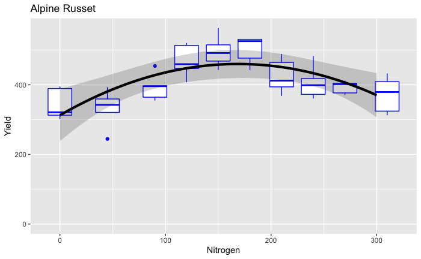

```r
# code for plotting
Nitrogen_range = seq(0,300,by=1)
expt2_deg2_means = emmeans(expt2_deg2,spec = 'Nitrogen',at=list(Nitrogen = Nitrogen_range))
expt2_deg2_means_summary = as.data.frame(summary(expt2_deg2_means,infer = c(T,F),level = 0.95))

# Make a base plot with boxplots of the data
base_plot_2 = ggplot(experiment2, aes(x=Nitrogen)) +
    geom_boxplot(aes(y=Yield, group = Nitrogen),color = 'blue', position = position_identity()) +
    ggtitle('Alpine Russet') + expand_limits(y=0)

# Then, add a line for the trend and a ribbon for the confidence intervals.
# Note, here we have to specify a new data table for the plot to use
base_plot_2 +
    geom_ribbon(data = expt2_deg2_means_summary,aes(ymin = lower.CL,ymax = upper.CL),alpha = 0.2) +
    geom_line(data = expt2_deg2_means_summary,aes(y = emmean),size=1.5)
```

## 1.5 Compare (visually) the trend estimated from Experiment2 to the trend estimated from Experiment1

Is the general shape of the trend similar? Is the width of the confidence interval band the same? Which experiment provided more information about the response of Yield to Nitrogen? How can you tell?

> The Q-Q plot for Experiment 2 has a better fit, with none of the points touching (or beyond) the dashed bounds, unlike in Experiment 1. In the Scale-Location Plot, the line is slightly flatter, with a more even spread of points, indicating that there is less variation in the standard deciations of our data across the levels of nitrogen. The boxplot, Alpine Russet, has smaller confidence levels, but there appear to be small dips around 50 and 250g of Nitrogen. This indicates that there may be a model with a better fit (perhaps degree 3).

# 2 Experiment 3

If Experiment 2 was better than Experiment 1, why not go further and use a different level of Nitrogen in every plot? Experiment 3 has the following design:

- 50 nitrogen regimes distributed equally from 0 to 300 lbs / acre at emergence
- 1 rep (plot) / Nitrogen level
- Response: total yield

The data for this experiment is here:

```r
experiment3 = read.csv('~/Desktop/R_Projects/PLS205_Winter2021/PLS205_Winter2021/data/Experiment3.csv',stringsAsFactors=F)
str(experiment3)
```

```
'data.frame':   50 obs. of  3 variables:
 $ Plot    : int  1 2 3 4 5 6 7 8 9 10 ...
 $ Nitrogen: num  126.5 88.6 31.6 297.3 196.1 ...
 $ Yield   : num  471 432 340 429 441 ...
```

## 2.1 Prepare the design table for Experiment3

| Structure | Variable | Type | # levels | EU |
| --- | --- | --- | --- | --- |
| Treatment | Nitrogen | Numeric | 50 | NitrogenF |
| Design | NitrogenF | Categorical | 50 |  |
|  | Plot | Categorical | 50 |  |
| Response | Yield | Numeric | 50 |  |

## 2.2 Following the same strategy as above, select a polynomial trend model for Yield~f(Nitrogen) based on the data from Experiment3

Be careful about specifying this model using all rules about turning a design table into a model in R!

```r
# adding NitrogenF to the data
experiment3$NitrogenF <- as.factor(experiment3$Nitrogen)

# code for full model
expt3_full_trend <- lm(Yield ~ I(Nitrogen) + I(Nitrogen^2) + I(Nitrogen^3) + I(Nitrogen^4) + I(Nitrogen^5), data = experiment3)

# running the ANOVA
anova(expt3_full_trend)
```

```
Analysis of Variance Table

Response: Yield
              Df Sum Sq Mean Sq F value    Pr(>F)
I(Nitrogen)    1  21163   21163 11.6956  0.001362 **
I(Nitrogen^2)  1  75787   75787 41.8826 6.828e-08 ***
I(Nitrogen^3)  1   2613    2613  1.4440  0.235922
I(Nitrogen^4)  1  11836   11836  6.5411  0.014063 *
I(Nitrogen^5)  1    601     601  0.3321  0.567366
Residuals     44  79618    1810
---
Signif. codes:  0 ‘***’ 0.001 ‘**’ 0.01 ‘*’ 0.05 ‘.’ 0.1 ‘ ’ 1
```

```r
# code for reduced model
expt3_deg4 <- lm(Yield ~ I(Nitrogen) + I(Nitrogen^2) + I(Nitrogen^3) + I(Nitrogen^4), data = experiment3)

# running the ANOVA
anova(expt3_deg4)
```

```
Analysis of Variance Table

Response: Yield
              Df Sum Sq Mean Sq F value   Pr(>F)
I(Nitrogen)    1  21163   21163 11.8718 0.001245 **
I(Nitrogen^2)  1  75787   75787 42.5136 5.26e-08 ***
I(Nitrogen^3)  1   2613    2613  1.4657 0.232338
I(Nitrogen^4)  1  11836   11836  6.6396 0.013324 *
Residuals     45  80219    1783
---
Signif. codes:  0 ‘***’ 0.001 ‘**’ 0.01 ‘*’ 0.05 ‘.’ 0.1 ‘ ’ 1
```

> In a degree 5 polynomial, the fifth term has a low F value and a high p value, indicating that this term should be dropped. In a degree 4 polynomial, the fourth term has a relatively high F value (6.6396) and a low p value, indicating that it is unlikely we got this high f value by random chance (though, of course, it is still possible).

## 2.3 Compare (visually) the trend estimates from Experiment 2 and Experiment 3.

Is there any reason that you can think of of favoring Experiment2 over Experiment 3 in this context?

```r
# code for diagnostics
pls205_diagnostics(expt3_deg4, EU = 'NitrogenF')


# code for plotting
Nitrogen_range = seq(0, 300, by=1)
expt3_deg4_means = emmeans(expt3_deg4,spec = 'Nitrogen', at=list(Nitrogen = Nitrogen_range))
expt3_deg4_means_summary = as.data.frame(summary(expt3_deg4_means, infer = c(T, F), level = 0.95))

# Make a base plot with boxplots of the data
base_plot_3 = ggplot(experiment3, aes(x=Nitrogen)) +
    geom_boxplot(aes(y=Yield, group = Nitrogen),color = 'blue', position = position_identity()) +
    ggtitle('Alpine Russet') + expand_limits(y=0)

# Then, add a line for the trend and a ribbon for the confidence intervals.
# Note, here we have to specify a new data table for the plot to use
base_plot_3 +
    geom_ribbon(data = expt3_deg4_means_summary,aes(ymin = lower.CL,ymax = upper.CL),alpha = 0.2) +
    geom_line(data = expt3_deg4_means_summary,aes(y = emmean),size=1.5)
```

[output not shown]